# 2021_British_GP_Sprint_Analysis

Jose Delatorre

2022-08-30

# Formula 1 Sprint Qualifying Analysis

The purpose of this analysis is to determine how sprint qualifying races for the 2021 and 2022 seasons of Formula 1 (F1) have changed the outcomes of the race weekend and the race itself. The concept of sprint qualifying format for F1 was introduced in the 2021 season changes such that three race weekends in a season will be utilizing the spring qualifying races.

A normal Formula 1 race weekend consists of about three days of on track time with the cars. Fridays (Day 1) are Free Practice Sessions (FP) where teams are able to test out the track and car setups over two separate 1-hour sessions. Saturdays are a mix of the final FP session for a total of three FP sesssions and three rounds of lap-time based qualifying sessions durin which the bottom 5 are ‘eliminated’ per session. A drivers elimination from the qualifying session will determine their position on the starting grid for Day 3 which is the Grand Prix running for a minimum of 305km (190miles) plus one lap. The only exception to this metric is the Monaco Grand Prix which is a distance of 260km (160mi).

This race weekend setup is modified slightly for sprint qualifying races. Day 1 is condensed to a single Free Practice session superseded by lap-time based qualifying. Day 2 starts with a second Free Practice session which is followed by the sprint race lasting for a total of 100km (62mi). Day 3 remains unchanged consisting of only the Grand Prix with the starting grid positions now determined by the results of the Sprint Race. For more info regarding Formula 1 Sprint races go here

## Ask

### Question 1

How much do positions change between the lap-time based qualifying, sprint-race qualifying and the full Grand Prix?

### Question 2

Is the pole sitting driver after the lap-time based qualifying sessions also the driver to win the sprint qualifying race and in turn that respective Grand Prix?

## Prepare

### Importing the data for analysis

The data for this analysis was downloaded via Kaggle after which it is loaded into SQL and RStudio using a table

```r
# Dataset 1: Sprint results
sprint_results <- data.frame(read.table("F1_Data_1950-2022/sprint_results.csv",header=TRUE, sep=","))
# Dataset 2: Formula 1 Race Data from 1950-2022
races <- data.frame(read.table("F1_Data_1950-2022/races.csv",header=TRUE,sep=","))
# Dataset 3: Comprehensive Driver Data
drivers <- data.frame(read.table("F1_Data_1950-2022/drivers.csv",header = TRUE,sep=","))
# Dataset 4: Grand Prix Results
results <- data.frame(read.table("F1_Data_1950-2022/results.csv", header= TRUE,sep = ","))
```

## Process - Cleaning the Data

After the data has been imported, it is recommended the data be cleaned to remove any unnecessary clutter from the three tables. Cleaning the data will help with reducing the amount of clutter for each of the tables which will become especially important when joining the tables in the next few steps. Taking a look at each of the datasets using the View() function and remove any nulls.

```r
sprint_results <- sprint_results[-c(13,16)]
results <- subset(results,select = -c(13,18))
drivers <- subset(drivers, select = -c(dob,url,nationality))
races <- races[-c(8:18)]
```

RUN ONLY ONCE, IT WILL CREATE AN ERROR

Once the unnecessary columns have been removed, join sprint_results and drivers tables based on the driverId, this should then create a much smaller table for us to view the results of the sprint qualifying races with the drivers names shown.

```r
sprints_x_driver <- merge(sprint_results,drivers, by = "driverId")
sprints_x_driver <- merge(sprints_x_driver,races, by = "raceId")
```

Verify that the two tables have merged correctly and then perform a secondary join between ‘sprints_merged’ and ‘races’ using “raceId” as the primary key, overwriting the old ‘sprints_x_driver’ dataset

### Second Join - Drivers and Results

```r
GP_results <- merge(results,drivers, by = "driverId")
GP_results <- merge(GP_results,races, by = "raceId")
GP_results <- GP_results[-c(3,4,17)]
```

```r
# Confirm join success
# If you have not done so, see what values are associated with each column
head(GP_results)
```

```
##   raceId driverId number.x grid position positionText positionOrder points laps
## 1      1       15        9   20        3            3             3      6   58
## 2      1        6       17   11      \\N            R            18      0   17
## 3      1        7       11   17        8            8             8      1   58
## 4      1       12        8   14      \\N            R            17      0   24
## 5      1        8        4    7       15           15            15      0   55
## 6      1       17       14    8       12           12            12      0   57
##   time.x fastestLap rank fastestLapTime fastestLapSpeed number.y code  forename
## 1 +1.604         50   10       1:28.916         214.706      \\N  TRU     Jarno
## 2    \\N          6   18       1:29.923         212.301      \\N  NAK    Kazuki
## 3 +6.298         50   17       1:29.823         212.537      \\N  BOU Sébastien
## 4    \\N         17   19       1:30.502         210.943      \\N  PIQ    Nelson
## 5    \\N         35    7       1:28.488         215.744        7  RAI      Kimi
## 6    \\N         38    8       1:28.508         215.695      \\N  WEB      Mark
##      surname year round circuitId                  name       date   time.y
## 1     Trulli 2009     1         1 Australian Grand Prix 2009-03-29 06:00:00
## 2   Nakajima 2009     1         1 Australian Grand Prix 2009-03-29 06:00:00
## 3   Bourdais 2009     1         1 Australian Grand Prix 2009-03-29 06:00:00
## 4 Piquet Jr. 2009     1         1 Australian Grand Prix 2009-03-29 06:00:00
## 5  Räikkönen 2009     1         1 Australian Grand Prix 2009-03-29 06:00:00
## 6     Webber 2009     1         1 Australian Grand Prix 2009-03-29 06:00:00
```

```r
head(sprints_x_driver)
```

```
##   raceId driverId resultId constructorId number.x grid position positionText
## 1   1061        1        2           131       44    1        2            2
## 2   1061        4        7           214       14   11        7            7
## 3   1061      849       17             3        6   18       17           17
## 4   1061      841       15            51       99   14       15           15
## 5   1061      832       11             6       55    9       11           11
## 6   1061      830        1             9       33    2        1            1
##   positionOrder points laps    time.x fastestLap fastestLapTime      driverRef
## 1             2      2   17    +1.430         17       1:29.937       hamilton
## 2             7      0   17   +43.527         17       1:31.773         alonso
## 3            17      0   17   +55.162         17       1:32.143         latifi
## 4            15      0   17   +53.225         14       1:32.457     giovinazzi
## 5            11      0   17   +47.798         10       1:31.991          sainz
## 6             1      3   17 25:38.426         14       1:30.013 max_verstappen
##   number.y code forename    surname year round circuitId               name
## 1       44  HAM    Lewis   Hamilton 2021    10         9 British Grand Prix
## 2       14  ALO Fernando     Alonso 2021    10         9 British Grand Prix
## 3        6  LAT Nicholas     Latifi 2021    10         9 British Grand Prix
## 4       99  GIO  Antonio Giovinazzi 2021    10         9 British Grand Prix
## 5       55  SAI   Carlos      Sainz 2021    10         9 British Grand Prix
## 6       33  VER      Max Verstappen 2021    10         9 British Grand Prix
##         date   time.y
## 1 2021-07-18 14:00:00
## 2 2021-07-18 14:00:00
## 3 2021-07-18 14:00:00
## 4 2021-07-18 14:00:00
## 5 2021-07-18 14:00:00
## 6 2021-07-18 14:00:00
```

### Filter the data

Now that the datasets are condensed into a single working table we can utilize the single table to filter as necessary. The first filter to be applied will be separating the 2021 and 2022 seasons, the second will be by the Grand Prix, the third and final filter will be applied to reduce the analysis to the top five drivers per event.

#### Filter by Grand Prix, Year, and Top Five of Sprint Qualifying

```r
#Filter by Year, Grand Prix, and sort to only have the top five drivers finishing the sprint race
Sprint_GP01_2021 <- filter(sprints_x_driver, year=='2021'& circuitId =='9' & position <=5)
```

```r
#Filter by Year and Year
Results_GP01_2021 <- filter(GP_results, year=='2021'& circuitId =='9' )
```

#### Top Five Drivers of Each Grand Prix

Grid = Starting grid position Position = final position at completion of race/sprint

```r
British_GP <- merge(Results_GP01_2021 ,Sprint_GP01_2021, by = 'driverId')
# Use \\ to bypass "\" which is considered an escape sequence
#The next line searches for all values with \N within the British_GP dataset and replaces them with a value of 0
British_GP[British_GP == "\\N"] <- 0
transform(British_GP, position.x = as.numeric(position.x))
```

```
##    driverId raceId.x number.x.x grid.x position.x positionText.x
## 1         1     1061         44      2          1              1
## 2         8     1061          7     13         15             15
## 3       815     1061         11      0         16             16
## 4       822     1061         77      3          3              3
## 5       830     1061         33      1          0              R
## 6       832     1061         55     10          6              6
## 7       839     1061         31      9          9              9
## 8       840     1061         18     14          8              8
## 9       841     1061         99     15         13             13
## 10      842     1061         10     11         11             11
## 11      844     1061         16      4          2              2
## 12      846     1061          4      5          4              4
## 13      849     1061          6     17         14             14
## 14      852     1061         22     16         10             10
```

[output cut: 121 more lines]

# Analysis

Upon looking at the combined results of the British Grand Prix it appears to be that there were significant changes during the races.

## 2021 British Grand Prix Sprint Qualifiying Results

Of the top five drivers positions on the starting grid there were a number of changes during the short 17 lap sprint. The largest of those changes was Red Bull Racing driver, Sergio Perez (PER), who started the sprint in 5th place but ended in 20th under a ‘Did Not Finish’or ’DNF’ status. As a result of this, McLaren driver, Lando Norris (NOR), who started the race in 6th managed to finish at P5. The 3rd and 4th positions, Mercedes driver Valterri Bottas (BOT) and Ferrari Driver Charles Leclerc (LEC) respectively, remained unchanged from starting grid of the sprint race to their final positions of sprint qualifying. Starting grid positions for 1st and 2nd place were initially Mercedes driver, Lewis Hamilton (HAM) followed by Red Bull driver, Max Verstappen(VER). These positions were eventually swapped as Verstappen overtook Hamilton and held the position until the end of the sprint.

# Share

## British Grand Prix Sprint and Race Results

```r
# Assign the variables BritishGP_Sprint for the ggplot associated to Sprint Race
British_SprintR <- ggplot(British_GP,aes(x = code.y, y = grid.x)) +
  geom_point(size = 4)+
  geom_segment(aes(x = code.x,
                   xend = code.x,
                   size = 0.1,
                   y = positionOrder.x,
                   yend = grid.x)) +
  labs(title = 'British GP Sprint Results: Grid vs Final Positions',
       caption = 'this is a caption')
  theme(axis.text.x = element_text(angle=65,vjust = 0.7))
```

[output not shown]

```r
British_GPR <- ggplot(British_GP,aes(x = code.y, y = grid.y)) +
  geom_point(size = 4)+
  geom_segment(aes(x = code.x,
                   xend = code.x,
                   size = 0.1,
                   y = positionOrder.y,
                   yend = grid.y)) +
  labs(title = 'British GP Results: Grid vs Final Positions',
       caption = 'this is a caption')
  theme(axis.text.x = element_text(angle=65,vjust = 0.7))
```

[output not shown]

```r
British_GPR_2 <- ggplot(British_GP,aes(x = grid.y, y = code.y)) +
  geom_point(size = 4)+
  geom_segment(aes(x = positionOrder.y,
                   xend = grid.y,
                   size = 0.1,
                   y = code.y,
                   yend = code.y)) +
  labs(title = 'British GP Results: Grid vs Final Positions',
       caption = 'this is a caption')
  theme(axis.text.x = element_text(angle=65,vjust = 0.7))
```

[output not shown]

[figure not shown]

```r
plot(British_SprintR)
```

[figure not shown]

```r
plot(British_GPR)
```

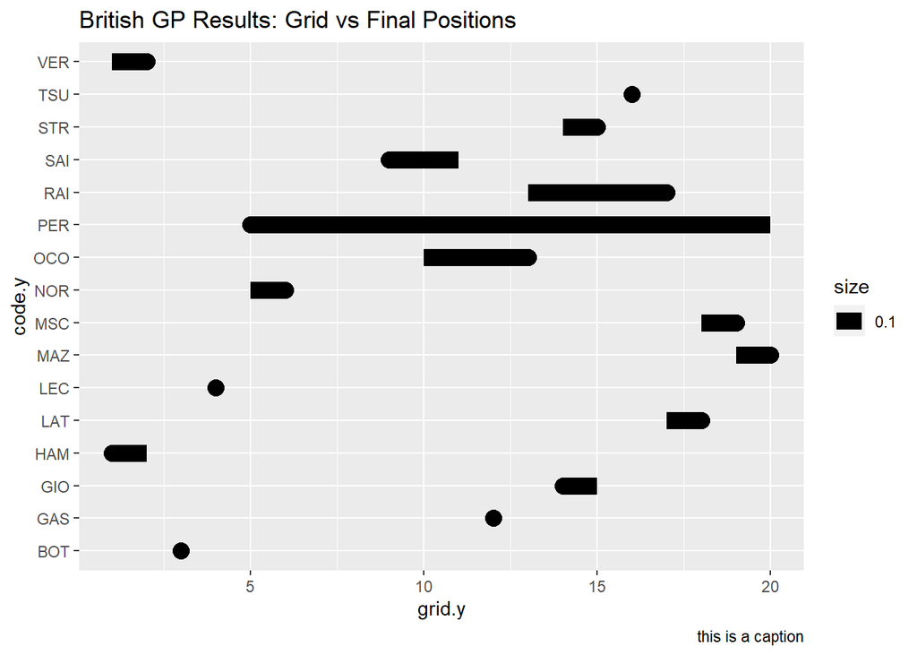

```r
plot(British_GPR_2)
```